# Generación de la matriz de distancias

Biogeografía (GEO-131)

2026-08-24

> Todas las prácticas de este curso están pensadas para realizarse con lápiz, papel y, a veces una calculadora (del móvil). Ocasionalmente, usarás alguna herramientas adicional.

## Fecha/hora de entrega

**Ver portal de la asignatura**

## Introducción

En esta práctica, compuesta de dos partes, nos enfocaremos en la **Generación de la Matriz de Distancias** entre puntos en un espacio bidimensional. La matriz de distancias es una herramienta crucial en la geografía, biogeografía, ecología y el análisis espacial, ya que permite cuantificar la proximidad entre diferentes puntos de interés, pero igualmente, sirve para cuantificar la similitud o disimilitud entre especies, sitios de muestreo, hábitats e incluso ecosistemas o biomas. Asimismo, la matriz de distancias es un requisito imprescindible cuando se necesita agrupar datos, especies, sitios, hábitats, e incluso para ordenarlos y establecer asociaciones entre especies, o entre especies y hábitats. En definitiva, es una herramienta de mucha utilidad.

Como métrica usaremos la distancia euclidiana. La distancia euclidiana es la más común de las métricas de este renglón, pero no necesariamente es la más idónea en todos los casos. Existen otras métricas de distancia, y te pido que leas este reciente artículo de Scheele et al. (2025), especialmente la sección “*Materials and Methods*” [(https://nsojournals.onlinelibrary.wiley.com/doi/10.1111/ecog.07612)](https://nsojournals.onlinelibrary.wiley.com/doi/10.1111/ecog.07612); pide ayuda a alguna IA con la terminología y la extracción de las principales ideas.

## Objetivos de la práctica

1. **Comprender y aplicar la distancia euclidiana** como métrica básica para calcular distancias entre puntos en un espacio bidimensional.
2. **Construir e interpretar una matriz de distancias**, identificando qué significan distancias grandes, intermedias o pequeñas en contextos espaciales y biométricos.
3. **Representar y analizar los resultados gráficamente**, mediante diagramas de dispersión y mapas de calor, integrando tanto cálculos manuales como el uso de R.

## Teoría

La distancia entre dos puntos $(x_i, y_i)$ y $(x_j, y_j)$ se puede calcular de múltiples formas. Nosotros utilizaremos la distancia euclidiana:

$$d_{ij} = \sqrt{(x_i - x_j)^2 + (y_i - y_j)^2}$$

La matriz de distancias es una matriz cuadrada donde cada elemento $d_{ij}$ representa la distancia entre los puntos $i$ y $j$.

## Ejercicio demostrativo

### Planteamiento del Problema

Consideremos tres puntos $A$, $B$ y $C$ en un plano bidimensional. Los puntos $A$ y $B$ estarán cercanos entre sí, mientras que el punto $C$ estará alejado de ambos. Las coordenadas de estos puntos son:

- Punto $A$: $(x_A, y_A) = (2, 2)$
- Punto $B$: $(x_B, y_B) = (3, 3)$
- Punto $C$: $(x_C, y_C) = (10, 10)$

Queremos calcular la matriz de distancias para estos tres puntos.

### A mano

Usaremos la **distancia euclidiana** entre dos puntos $P_i=(x_i,y_i)$ y $P_j=(x_j,y_j)$:

$$d_{ij} \;=\; \sqrt{(x_i-x_j)^2+(y_i-y_j)^2}$$

Con:

- $A=(2,2)$
- $B=(3,3)$
- $C=(10,10)$

#### 1) Distancia $d_{AB}$

$$\Delta x = 3-2 = 1,\quad \Delta y = 3-2 = 1$$
$$d_{AB}=\sqrt{1^2+1^2}=\sqrt{2}\approx 1.4142$$

#### 2) Distancia $d_{AC}$

$$\Delta x = 10-2 = 8,\quad \Delta y = 10-2 = 8$$
$$d_{AC}=\sqrt{8^2+8^2}=\sqrt{64+64}=\sqrt{128}=8\sqrt{2}\approx 11.3137$$

#### 3) Distancia $d_{BC}$

$$\Delta x = 10-3 = 7,\quad \Delta y = 10-3 = 7$$
$$d_{BC}=\sqrt{7^2+7^2}=\sqrt{49+49}=\sqrt{98}=7\sqrt{2}\approx 9.8995$$

### Matriz de distancias (exacta)

$$D=\begin{pmatrix}
0 & \sqrt{2} & 8\sqrt{2}\\[4pt]
\sqrt{2} & 0 & 7\sqrt{2}\\[4pt]
8\sqrt{2} & 7\sqrt{2} & 0
\end{pmatrix}$$

### Matriz de distancias (aproximada)

|  | A | B | C |
| --- | --- | --- | --- |
| **A** | 0.0000 | 1.4142 | 11.3137 |
| **B** | 1.4142 | 0.0000 | 9.8995 |
| **C** | 11.3137 | 9.8995 | 0.0000 |

### Demostración con código reproducible en R

Tendría que dar lo mismo que haciéndolo a mano. Primero, definimos las coordenadas de los puntos y calculamos las distancias entre ellos:

```r
# Coordenadas de los puntos
x_A <- 2; y_A <- 2
x_B <- 3; y_B <- 3
x_C <- 10; y_C <- 10

# Crear una matriz para almacenar las coordenadas
coords <- matrix(c(x_A, y_A, x_B, y_B, x_C, y_C), ncol = 2, byrow = TRUE)
rownames(coords) <- c("A", "B", "C")
colnames(coords) <- c("X", "Y")
knitr::kable(as.matrix(coords))
```

|  | X | Y |
| --- | --- | --- |
| A | 2 | 2 |
| B | 3 | 3 |
| C | 10 | 10 |

Representamos cada punto en un gráfico de dispersión.

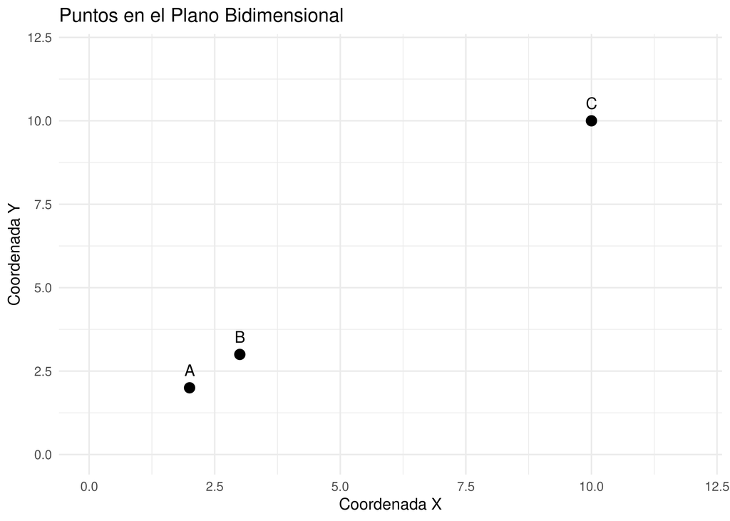

```r
library(ggplot2)
ggplot(data = as.data.frame(coords), aes(x = X, y = Y)) +
  geom_point(size = 3) +
  geom_text(aes(label = rownames(coords)), vjust = -1) +
  xlim(0, 12) + ylim(0, 12) +
  labs(title = "Puntos en el Plano Bidimensional", x = "Coordenada X", y = "Coordenada Y") +
  theme_minimal()
```

```r
# Función para calcular la matriz de distancias
distance_matrix <- function(coords) {
  dist(coords)
}

# Calcular la matriz de distancias
distances <- distance_matrix(coords)
knitr::kable(as.matrix(distances))
```

|  | A | B | C |
| --- | --- | --- | --- |
| A | 0.000000 | 1.414214 | 11.313709 |
| B | 1.414214 | 0.000000 | 9.899495 |
| C | 11.313709 | 9.899495 | 0.000000 |

La matriz de distancias se compone del triángulo inferior, el triángulo superior y la diagonal principal. La diagonal principal contiene ceros, ya que representa la distancia de un punto consigo mismo. En este caso, por tratarse de distancia euclidiana, los triángulos superior e inferior son simétricos entre sí, ya que la distancia entre dos puntos es la misma independientemente de la dirección en la que se mida.

## Tu turno

### Parte 1. Calcula una matriz de distancias

Mandato:

1. Elige un conjunto de los que aparecen abajo. Anuncia tu elección en el foro para evitar duplicidad.
2. Calcula la matriz de distancias entre tres puntos de coordenadas $X, Y$ diferentes.
3. Si puedes (si tienes lápiz), **en la matriz de distancias**, aplica un sombreado intenso a las distancias de la diagonal principal, un sombreado moderado a las distancias intermedias y sin sombreado a las distancias grandes. Si tienes lápices de distintos colores, podrías usar el tono para representar las distintas distancias (aunque esto es semiológicamente delicado).

> Podría servirte el representar los tres puntos de tu conjunto elegido en un plano cartesiano. Así podrás visualizar mejor su distribución.
4. Imagina que los datos son **del mundo real**: podrían ser coordenadas geográficas, medidas biométricas, características de especies, atributos de hábitats, etc.
   - Reflexiona sobre los resultados: ¿qué significado tienen las distancias pequeñas o grandes en ese contexto imaginario?
   - Formula al menos **dos preguntas** que podrían responderse a partir de la matriz de distancias en tu contexto imaginario. Ejemplos orientativos:
     - ¿Qué individuos (o sitios) se parecen más entre sí?
     - ¿Hay algún punto que aparezca como un “outlier” muy alejado de los demás?
     - ¿Qué implicaciones podría tener esto en biogeografía, conservación o en un análisis de similitud entre personas/especies/sitios?

> Cada quien puede imaginar la situación que prefiera, pero siempre recordando que se trata de **dos atributos medidos en tres elementos**.

#### Conjuntos (elige uno, anúncialo en el foro)

**Conjunto #1**

| ID Punto | X | Y |
| --- | --- | --- |
| A | 3 | 2 |
| B | 2 | 5 |
| C | 10 | 9 |

**Conjunto #2**

| ID Punto | X | Y |
| --- | --- | --- |
| A | 3 | 1 |
| B | 1 | 2 |
| C | 9 | 10 |

**Conjunto #3**

| ID Punto | X | Y |
| --- | --- | --- |
| A | 5 | 1 |
| B | 3 | 4 |
| C | 10 | 8 |

**Conjunto #4**

| ID Punto | X | Y |
| --- | --- | --- |
| A | 1 | 2 |
| B | 5 | 3 |
| C | 10 | 9 |

**Conjunto #5**

| ID Punto | X | Y |
| --- | --- | --- |
| A | 1 | 4 |
| B | 2 | 2 |
| C | 10 | 8 |

**Conjunto #6**

| ID Punto | X | Y |
| --- | --- | --- |
| A | 3 | 4 |
| B | 5 | 3 |
| C | 8 | 9 |

**Conjunto #7**

| ID Punto | X | Y |
| --- | --- | --- |
| A | 5 | 1 |
| B | 3 | 2 |
| C | 8 | 10 |

**Conjunto #8**

| ID Punto | X | Y |
| --- | --- | --- |
| A | 3 | 5 |
| B | 4 | 3 |
| C | 8 | 9 |

**Conjunto #9**

| ID Punto | X | Y |
| --- | --- | --- |
| A | 1 | 5 |
| B | 2 | 4 |
| C | 8 | 10 |

**Conjunto #10**

| ID Punto | X | Y |
| --- | --- | --- |
| A | 5 | 1 |
| B | 2 | 3 |
| C | 8 | 8 |

**Conjunto #11**

| ID Punto | X | Y |
| --- | --- | --- |
| A | 5 | 2 |
| B | 3 | 4 |
| C | 8 | 10 |

**Conjunto #12**

| ID Punto | X | Y |
| --- | --- | --- |
| A | 4 | 3 |
| B | 2 | 4 |
| C | 9 | 9 |

**Conjunto #13**

| ID Punto | X | Y |
| --- | --- | --- |
| A | 1 | 1 |
| B | 2 | 2 |
| C | 9 | 8 |

**Conjunto #14**

| ID Punto | X | Y |
| --- | --- | --- |
| A | 5 | 3 |
| B | 2 | 1 |
| C | 10 | 9 |

**Conjunto #15**

| ID Punto | X | Y |
| --- | --- | --- |
| A | 1 | 1 |
| B | 4 | 3 |
| C | 9 | 10 |

**Conjunto #16**

| ID Punto | X | Y |
| --- | --- | --- |
| A | 4 | 3 |
| B | 3 | 2 |
| C | 8 | 8 |

**Conjunto #17**

| ID Punto | X | Y |
| --- | --- | --- |
| A | 3 | 2 |
| B | 5 | 3 |
| C | 9 | 8 |

**Conjunto #18**

| ID Punto | X | Y |
| --- | --- | --- |
| A | 5 | 2 |
| B | 4 | 5 |
| C | 10 | 9 |

**Conjunto #19**

| ID Punto | X | Y |
| --- | --- | --- |
| A | 4 | 4 |
| B | 2 | 5 |
| C | 9 | 9 |

**Conjunto #20**

| ID Punto | X | Y |
| --- | --- | --- |
| A | 1 | 3 |
| B | 2 | 4 |
| C | 9 | 9 |

**Conjunto #21**

| ID Punto | X | Y |
| --- | --- | --- |
| A | 3 | 1 |
| B | 2 | 3 |
| C | 10 | 10 |

**Conjunto #22**

| ID Punto | X | Y |
| --- | --- | --- |
| A | 5 | 2 |
| B | 3 | 5 |
| C | 10 | 9 |

**Conjunto #23**

| ID Punto | X | Y |
| --- | --- | --- |
| A | 3 | 5 |
| B | 2 | 3 |
| C | 8 | 10 |

**Conjunto #24**

| ID Punto | X | Y |
| --- | --- | --- |
| A | 4 | 4 |
| B | 5 | 1 |
| C | 9 | 10 |

**Conjunto #25**

| ID Punto | X | Y |
| --- | --- | --- |
| A | 1 | 2 |
| B | 3 | 1 |
| C | 9 | 10 |

**Conjunto #26**

| ID Punto | X | Y |
| --- | --- | --- |
| A | 2 | 3 |
| B | 4 | 4 |
| C | 8 | 10 |

**Conjunto #27**

| ID Punto | X | Y |
| --- | --- | --- |
| A | 4 | 4 |
| B | 1 | 1 |
| C | 9 | 9 |

**Conjunto #28**

| ID Punto | X | Y |
| --- | --- | --- |
| A | 3 | 5 |
| B | 4 | 4 |
| C | 10 | 9 |

**Conjunto #29**

| ID Punto | X | Y |
| --- | --- | --- |
| A | 1 | 4 |
| B | 2 | 3 |
| C | 10 | 8 |

**Conjunto #30**

| ID Punto | X | Y |
| --- | --- | --- |
| A | 5 | 3 |
| B | 1 | 1 |
| C | 9 | 9 |

#### Soluciones numéricas

Te dejo a continuación la solución para cada conjunto. La solución sólo te servirá para comprobar que obtuviste un resultado correcto, pero debes incluir los cálculos en tu práctica.

Primero, en forma de “mapa de calor”, y un poco más abajo, en forma numérica (varias cifras significativas visibles). Nota que la diagonal en el mapa de calor tiene una orientación distinta a la de la forma numérica, pero el resultado para cada conjunto es idéntico.

```
## [1] "Conjunto 1"
```

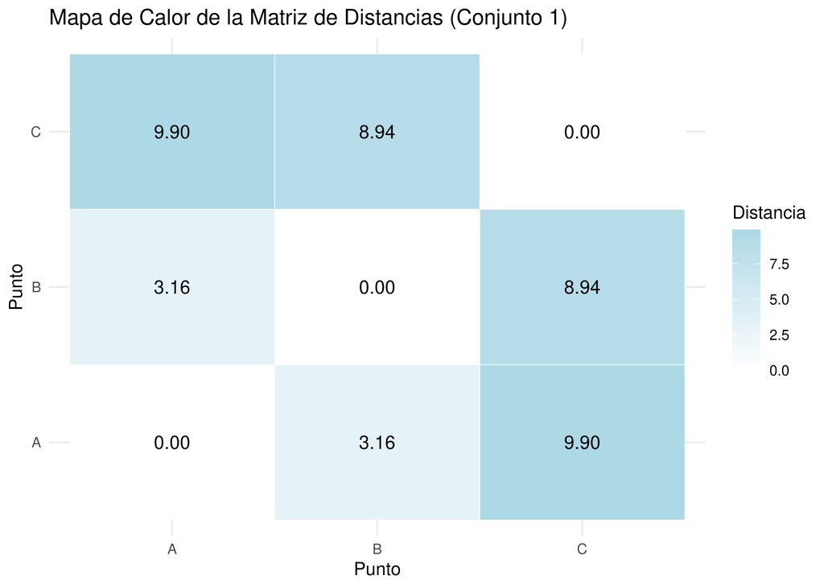

```
## [1] "Conjunto 2"
```

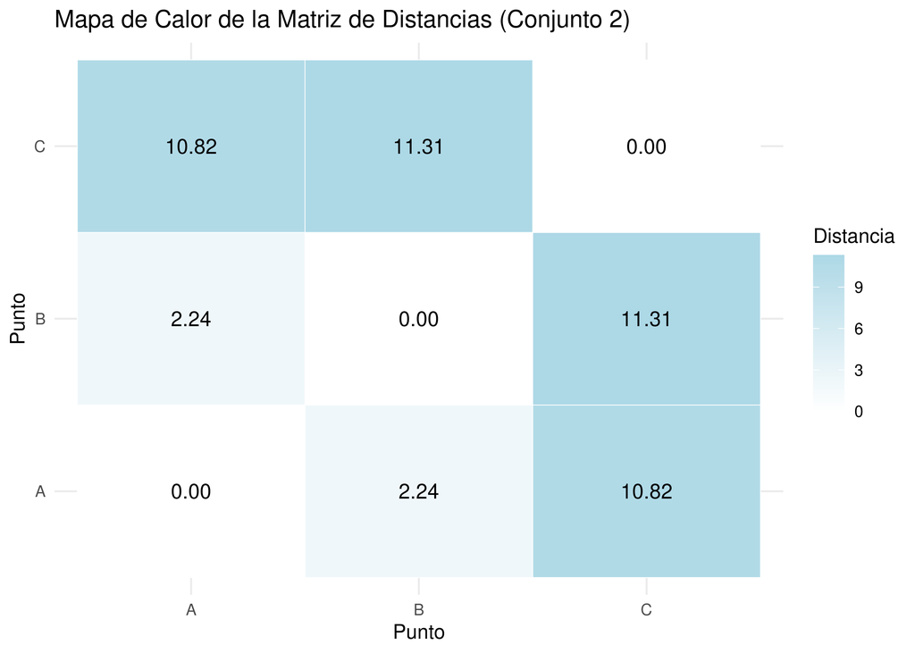

```
## [1] "Conjunto 3"
```

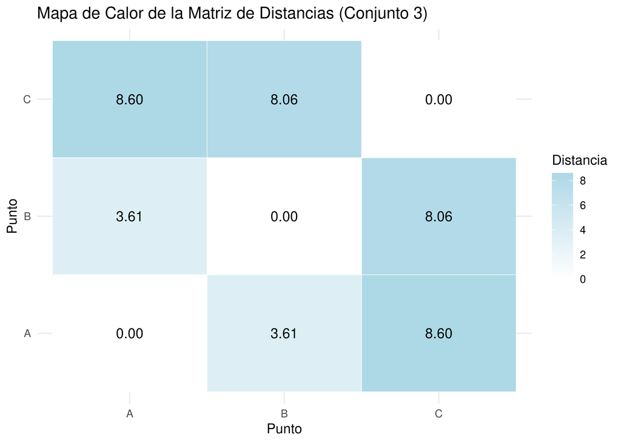

```
## [1] "Conjunto 4"
```

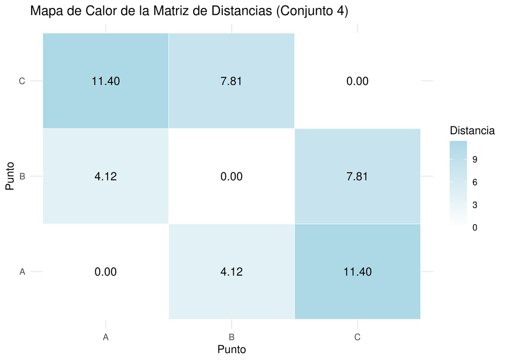

```
## [1] "Conjunto 5"
```

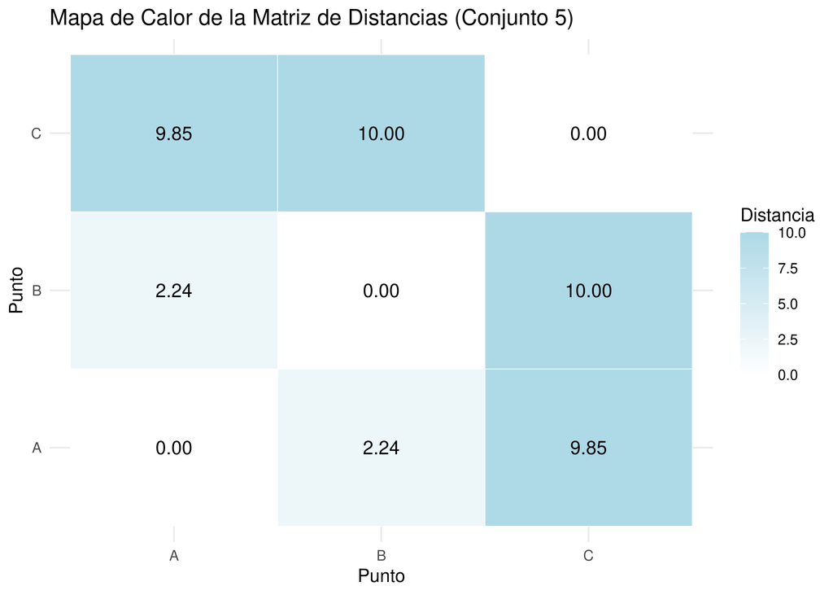

```
## [1] "Conjunto 6"
```

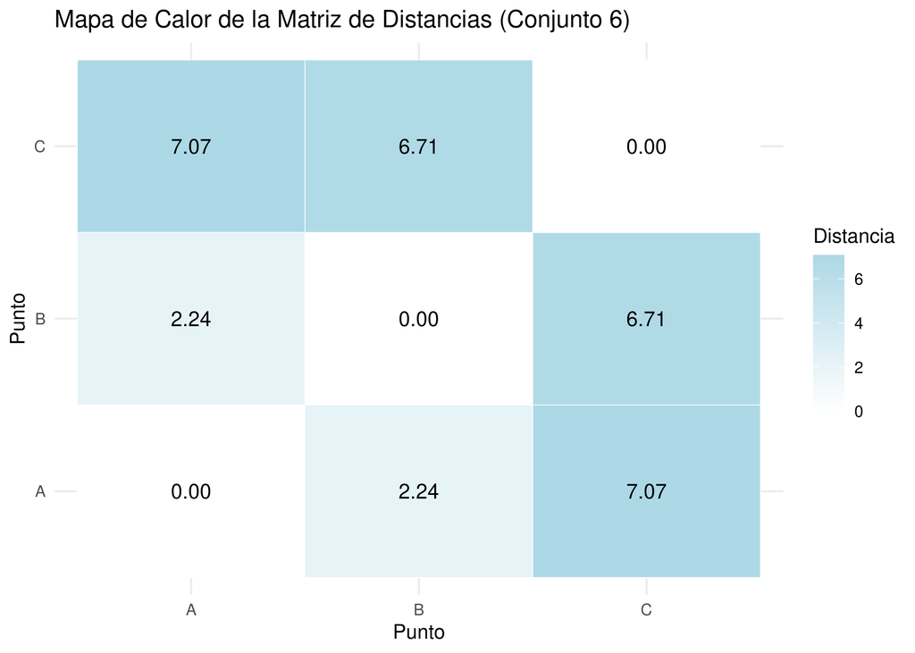

```
## [1] "Conjunto 7"
```

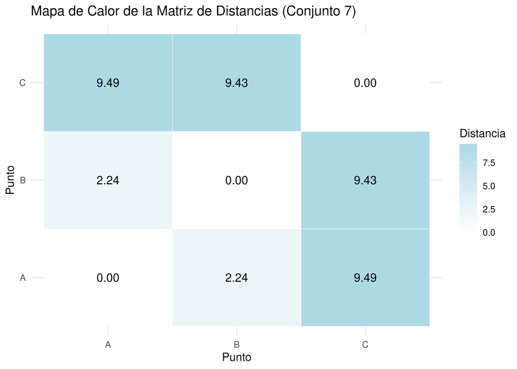

```
## [1] "Conjunto 8"
```

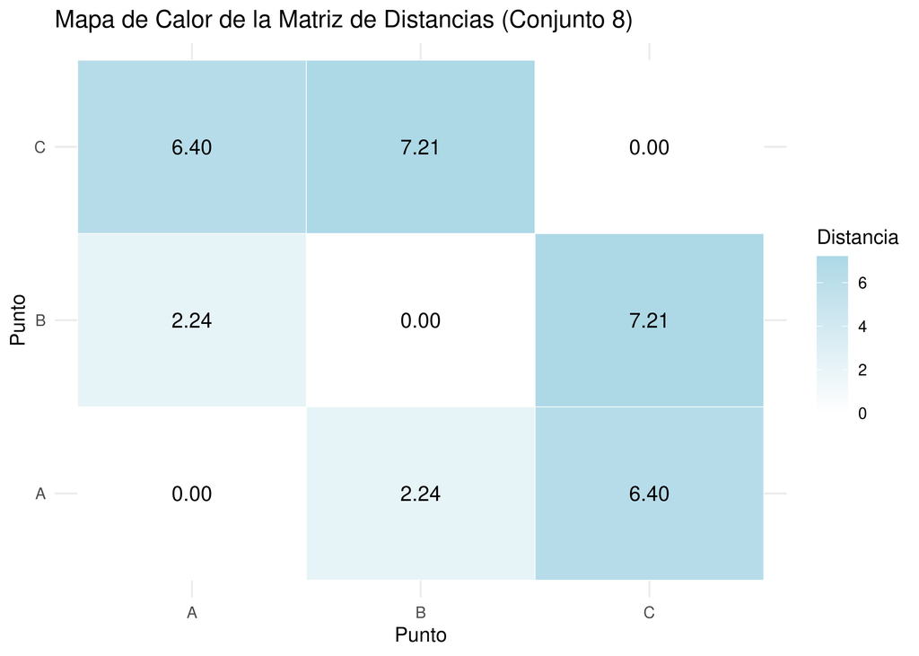

```
## [1] "Conjunto 9"
```

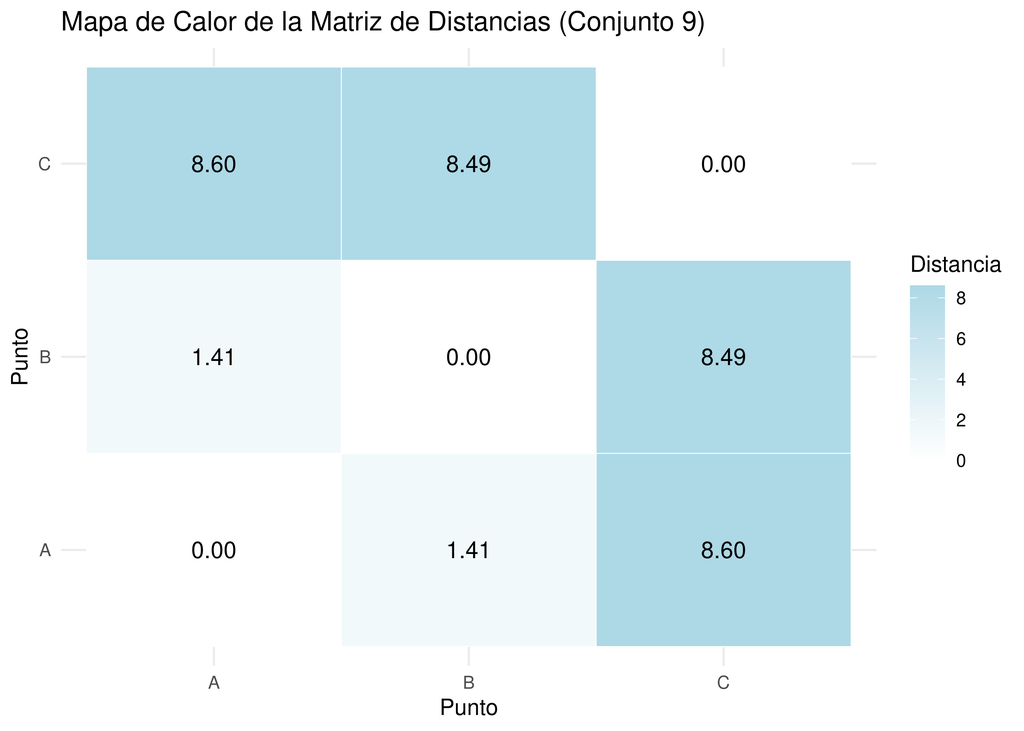

```
## [1] "Conjunto 10"
```

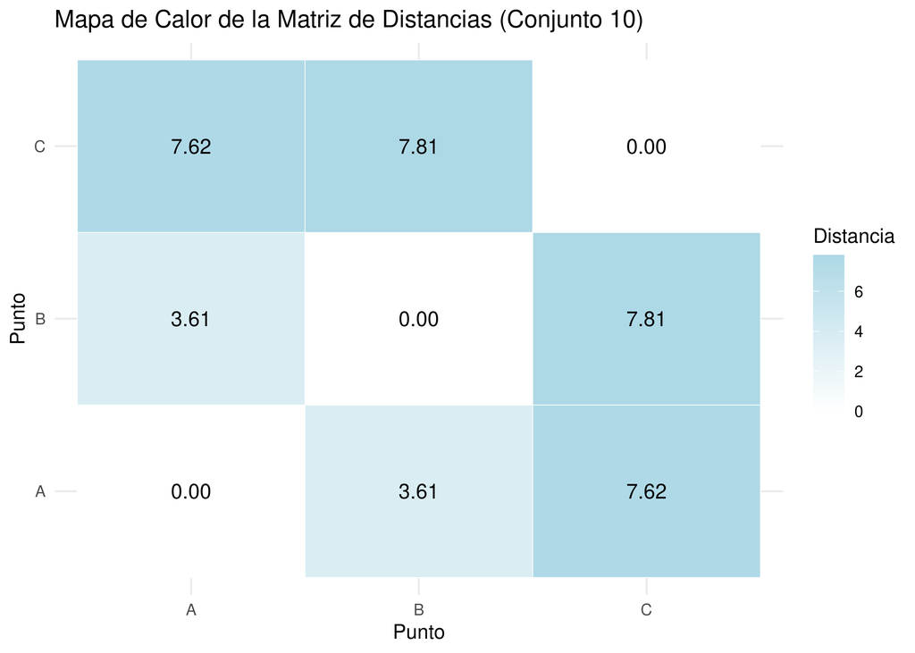

```
## [1] "Conjunto 11"
```

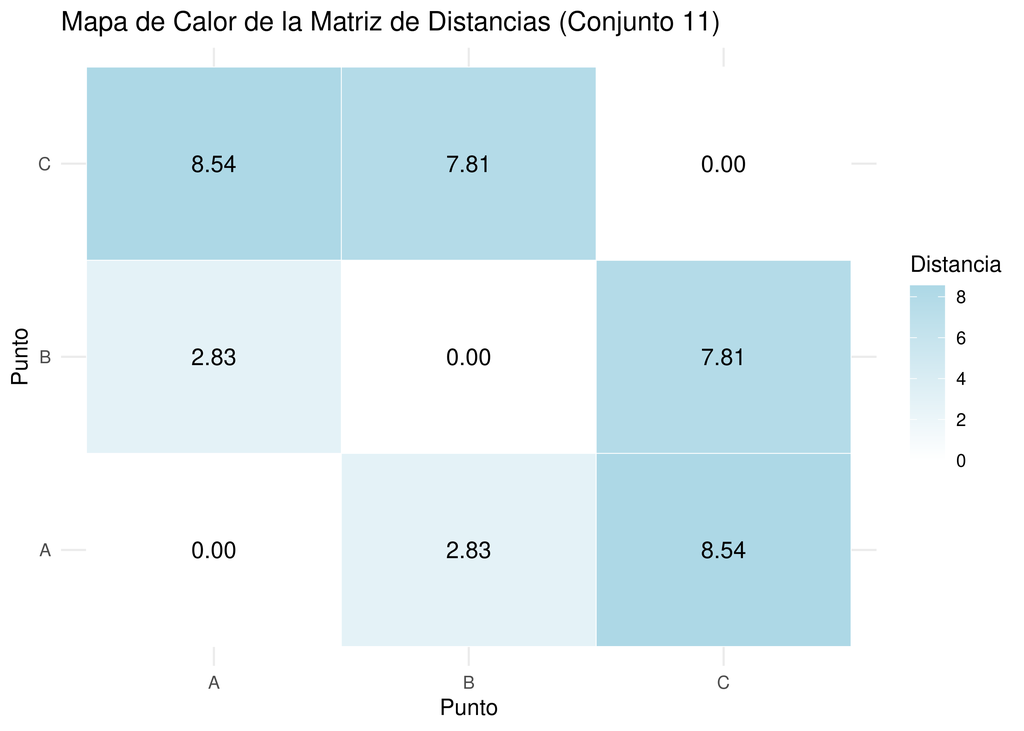

```
## [1] "Conjunto 12"
```

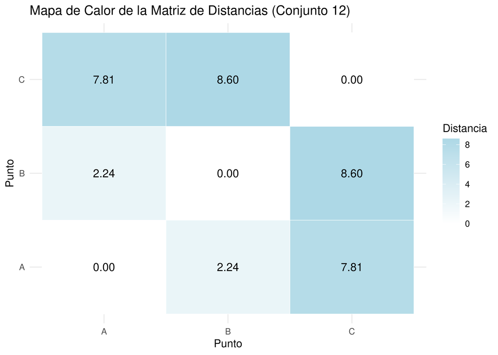

```
## [1] "Conjunto 13"
```

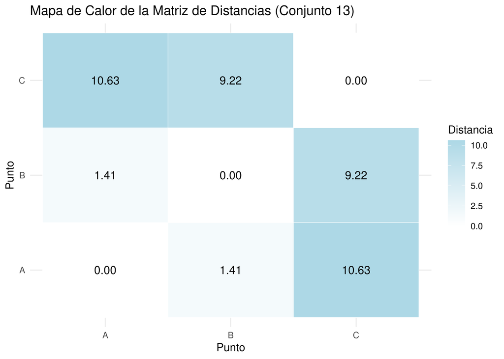

```
## [1] "Conjunto 14"
```

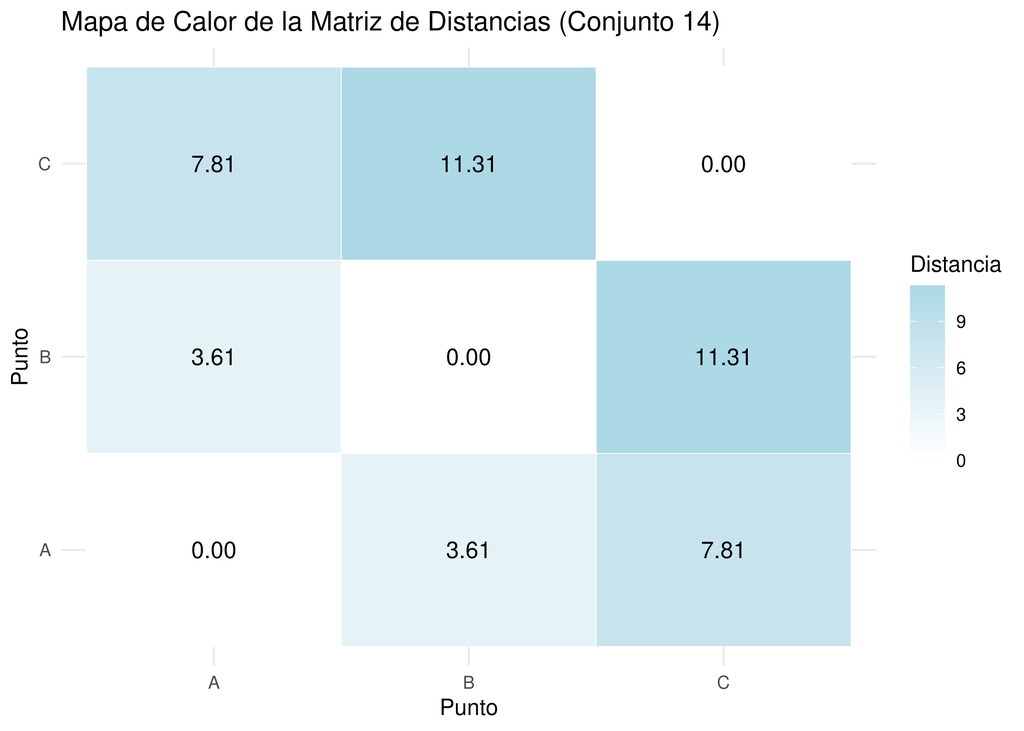

```
## [1] "Conjunto 15"
```

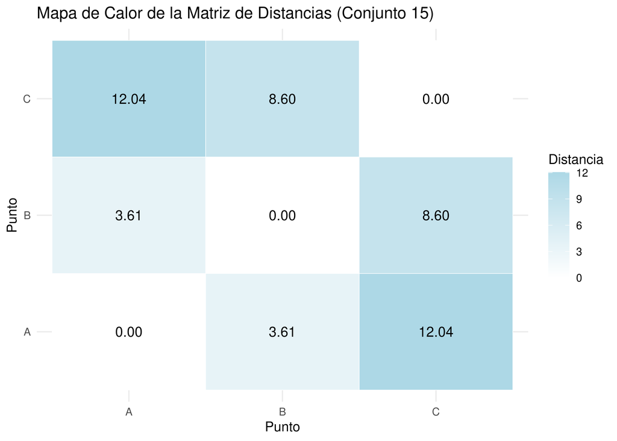

```
## [1] "Conjunto 16"
```

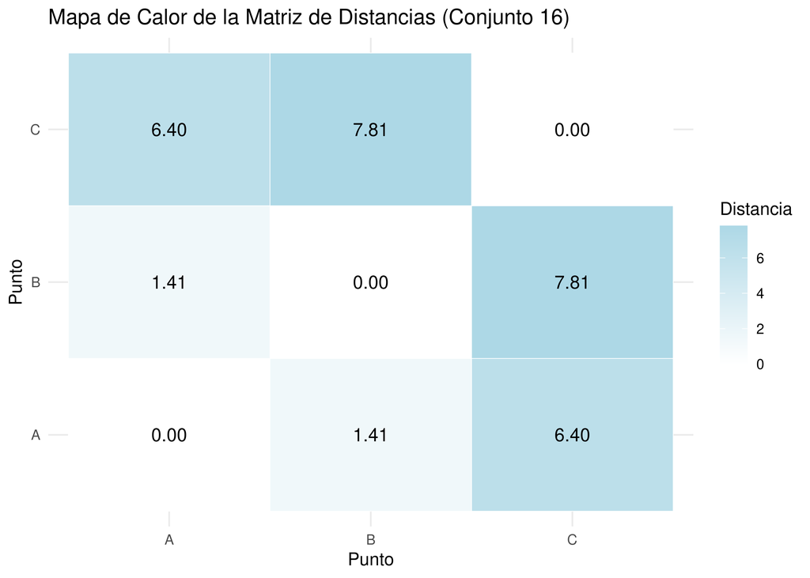

```
## [1] "Conjunto 17"
```

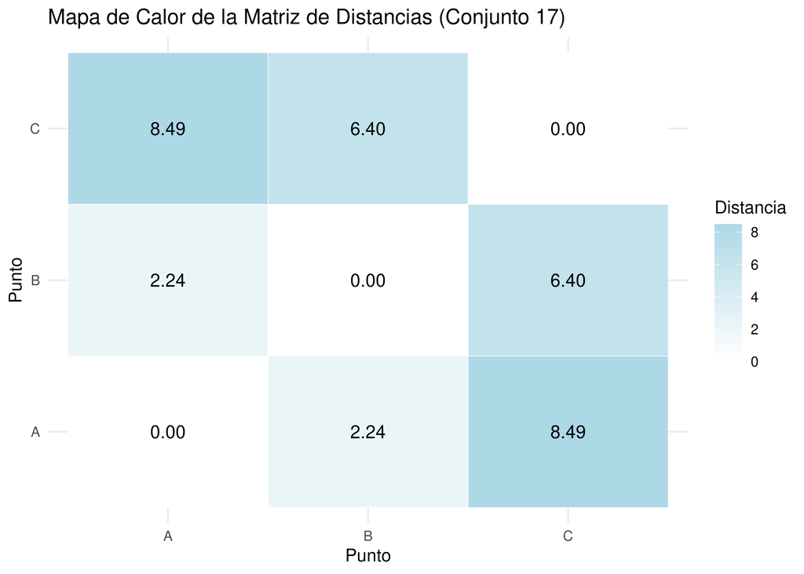

```
## [1] "Conjunto 18"
```

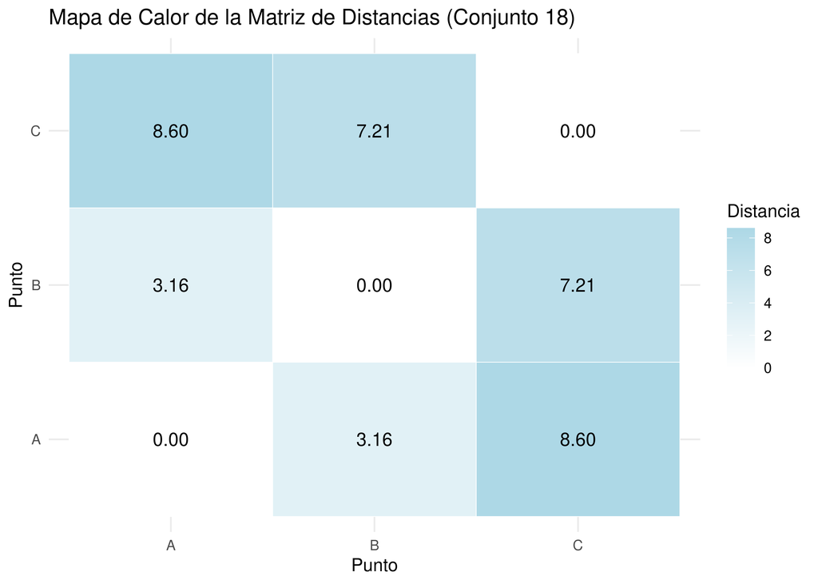

```
## [1] "Conjunto 19"
```

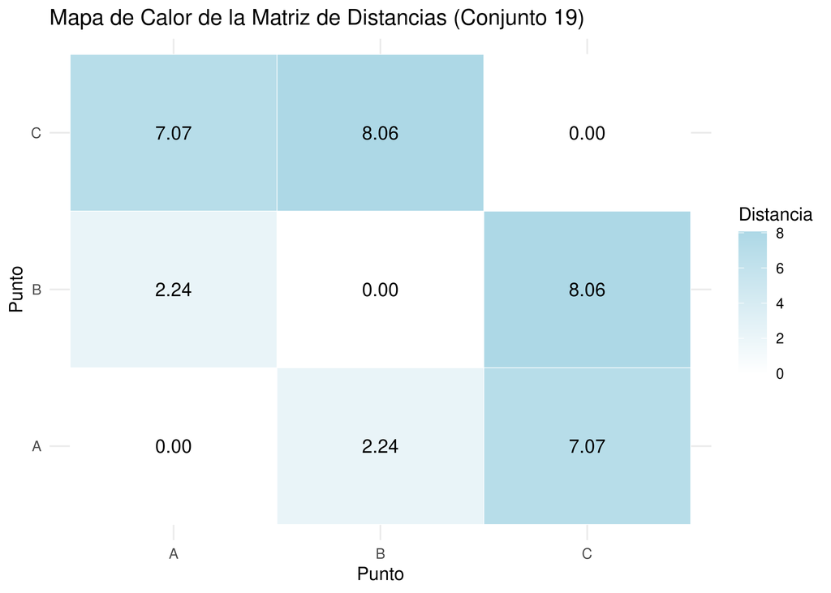

```
## [1] "Conjunto 20"
```

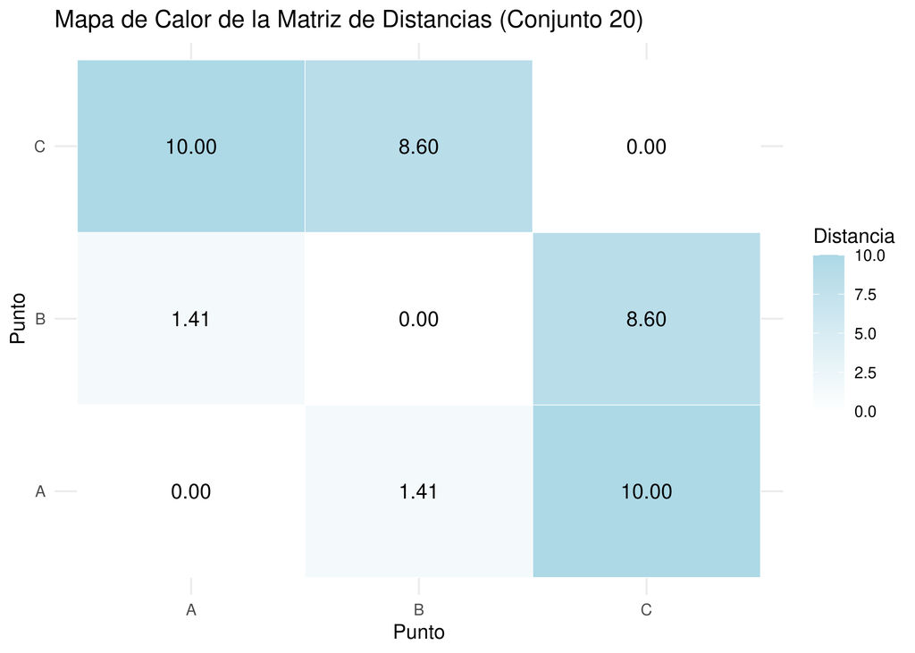

```
## [1] "Conjunto 21"
```

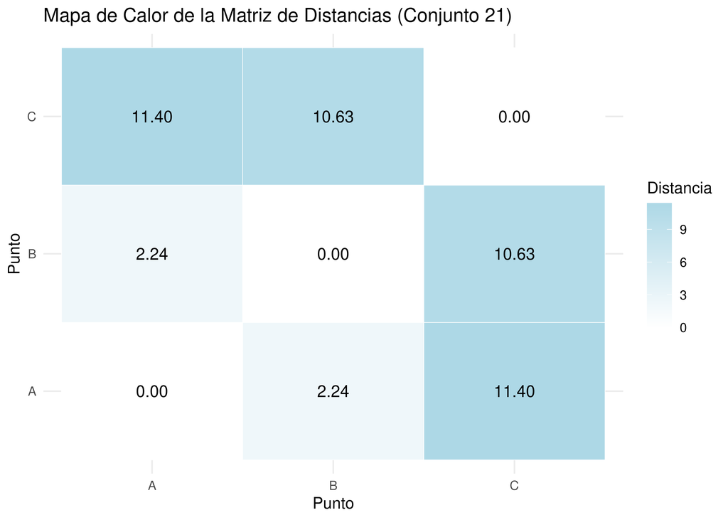

```
## [1] "Conjunto 22"
```

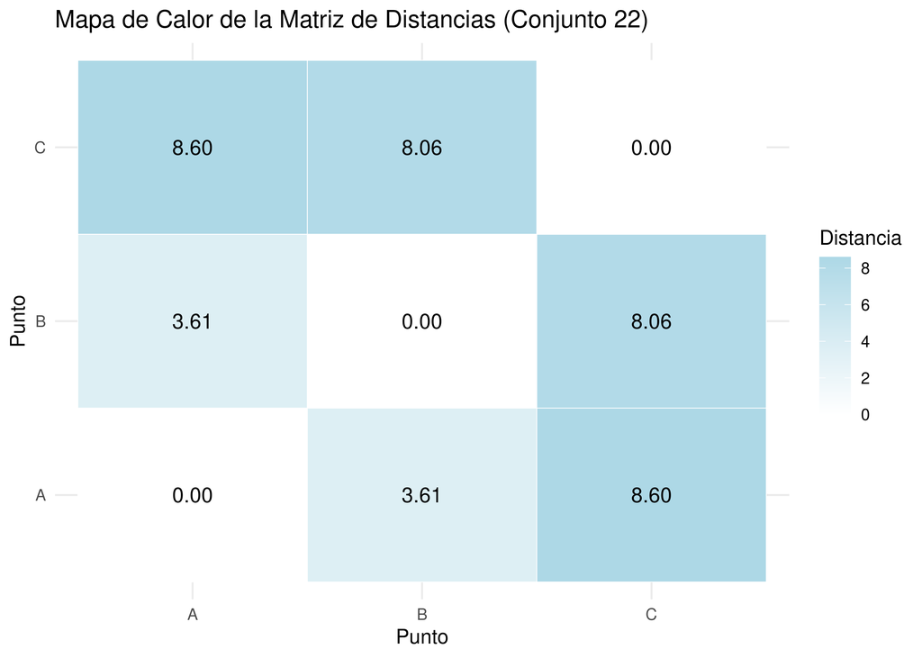

```
## [1] "Conjunto 23"
```

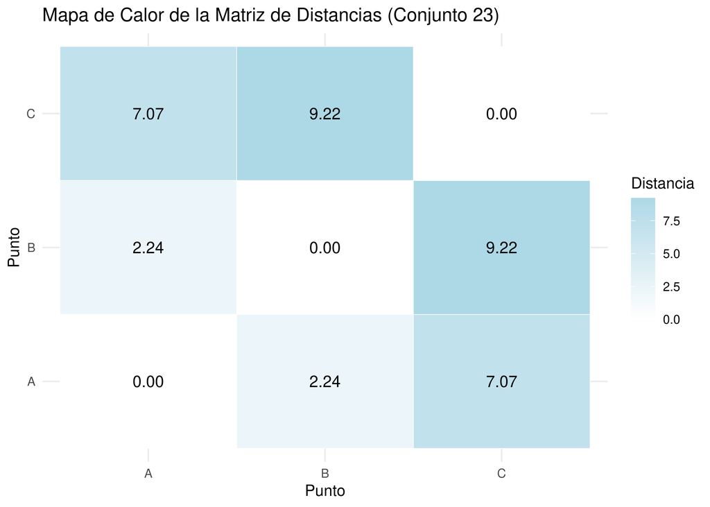

```
## [1] "Conjunto 24"
```

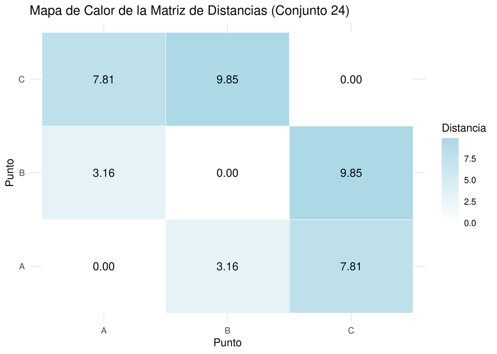

```
## [1] "Conjunto 25"
```

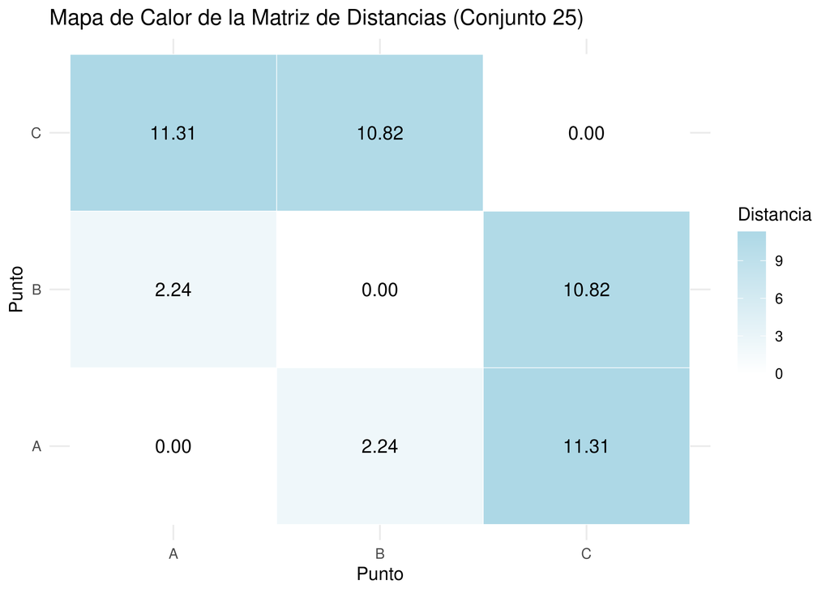

```
## [1] "Conjunto 26"
```

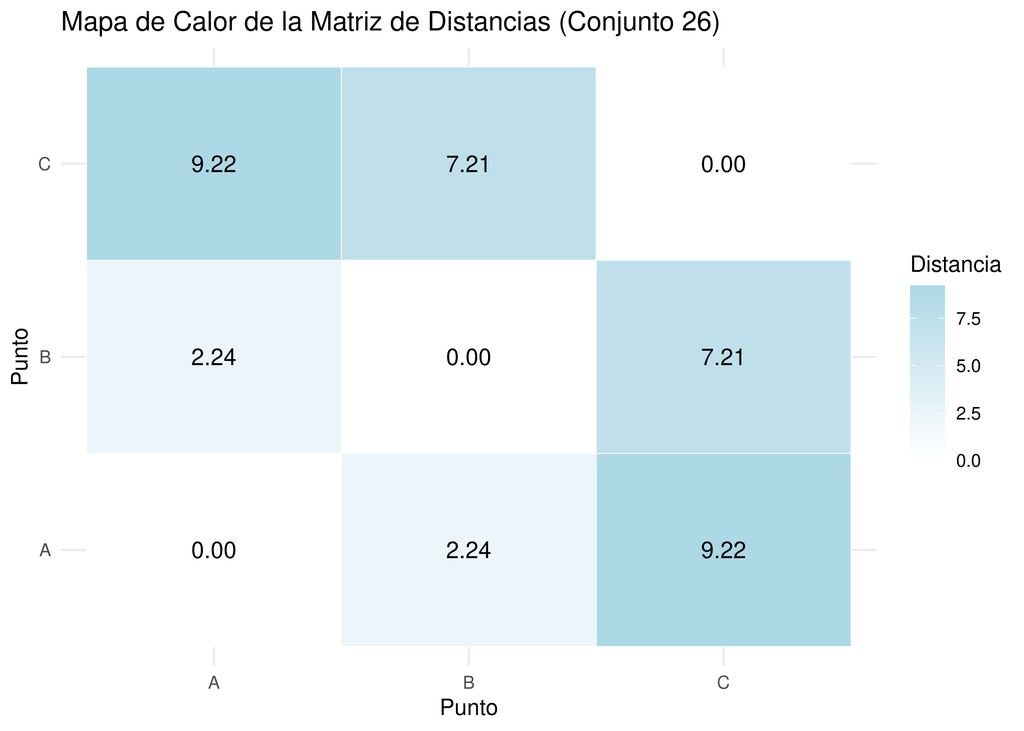

```
## [1] "Conjunto 27"
```

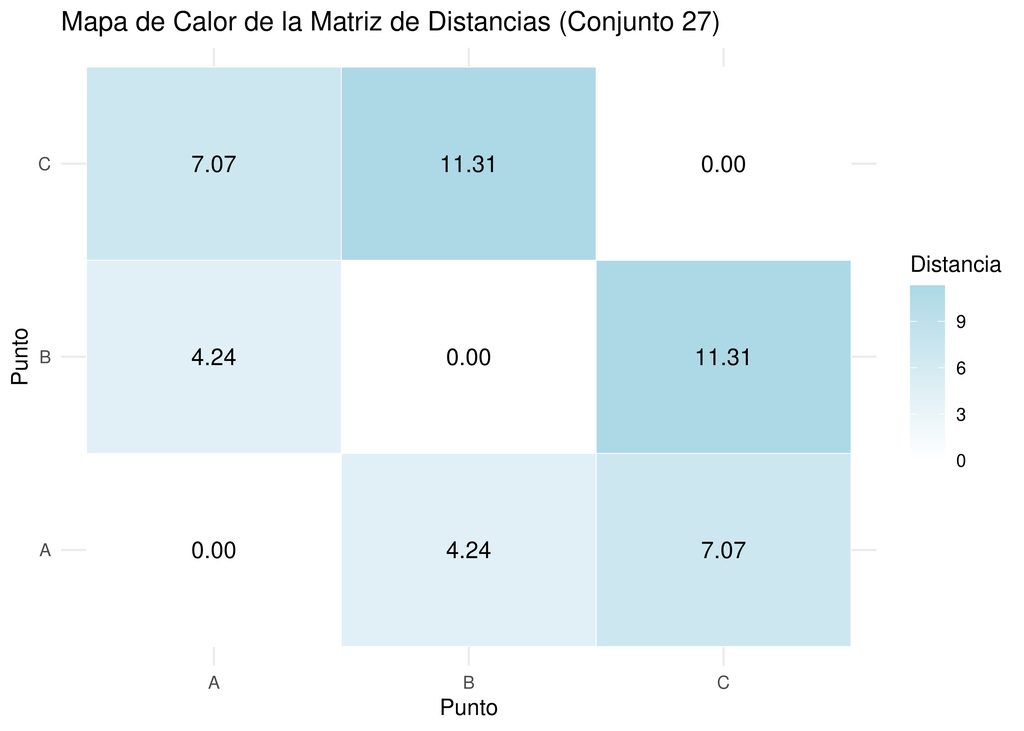

```
## [1] "Conjunto 28"
```

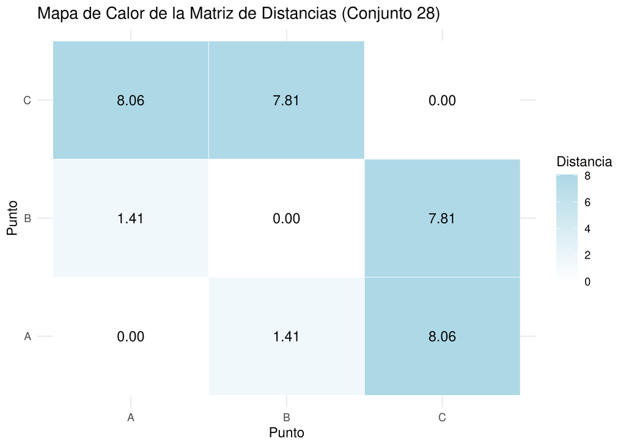

```
## [1] "Conjunto 29"
```

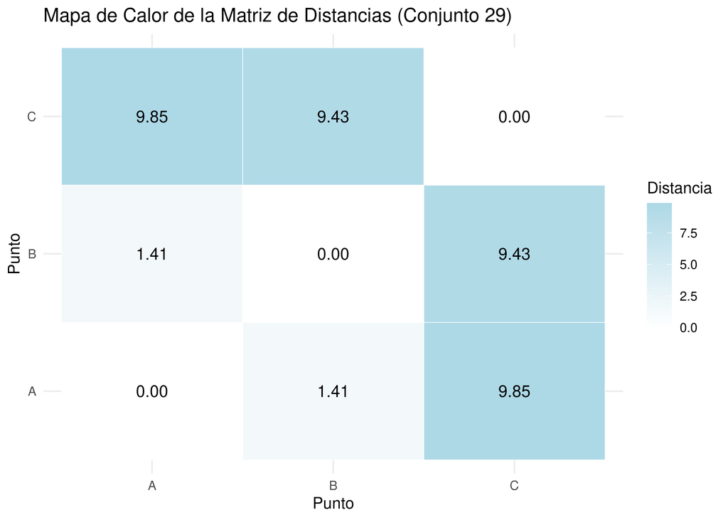

```
## [1] "Conjunto 30"
```

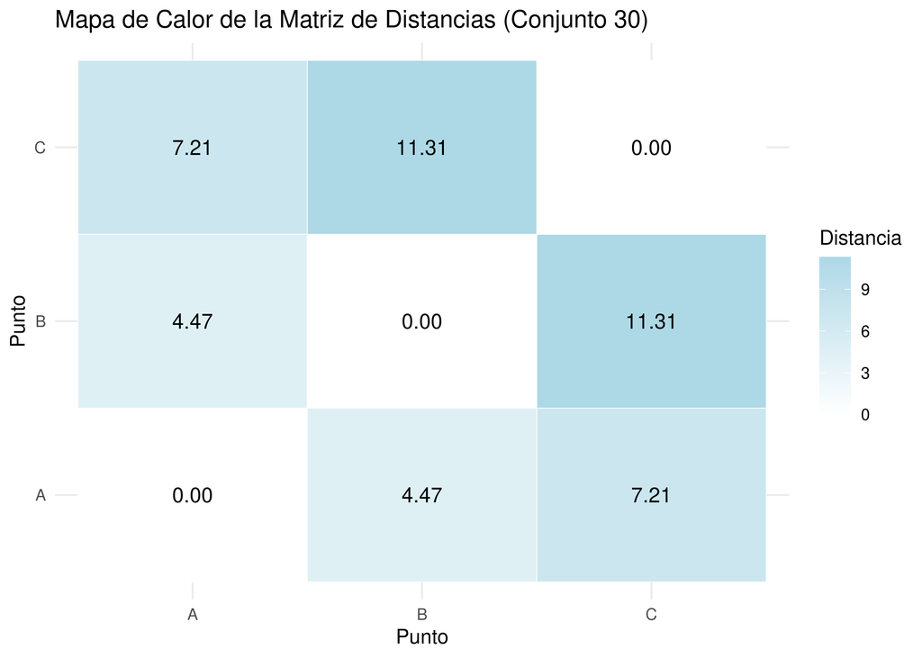

```
## $`Conjunto 1`
##          A        B        C
## A 0.000000 3.162278 9.899495
## B 3.162278 0.000000 8.944272
## C 9.899495 8.944272 0.000000
##
## $`Conjunto 2`
##           A         B        C
## A  0.000000  2.236068 10.81665
## B  2.236068  0.000000 11.31371
## C 10.816654 11.313708  0.00000
##
## $`Conjunto 3`
##          A        B        C
## A 0.000000 3.605551 8.602325
## B 3.605551 0.000000 8.062258
## C 8.602325 8.062258 0.000000
##
## $`Conjunto 4`
##           A        B        C
## A  0.000000 4.123106 11.40175
## B  4.123106 0.000000  7.81025
## C 11.401754 7.810250  0.00000
##
## $`Conjunto 5`
##          A         B         C
## A 0.000000  2.236068  9.848858
## B 2.236068  0.000000 10.000000
## C 9.848858 10.000000  0.000000
##
## $`Conjunto 6`
##          A        B        C
## A 0.000000 2.236068 7.071068
## B 2.236068 0.000000 6.708204
## C 7.071068 6.708204 0.000000
##
## $`Conjunto 7`
##          A        B        C
## A 0.000000 2.236068 9.486833
## B 2.236068 0.000000 9.433981
```

[output cut: 124 more lines]

```
## A 0.000000 1.414214 8.062258
## B 1.414214 0.000000 7.810250
## C 8.062258 7.810250 0.000000
##
## $`Conjunto 29`
##          A        B        C
## A 0.000000 1.414214 9.848858
## B 1.414214 0.000000 9.433981
## C 9.848858 9.433981 0.000000
##
## $`Conjunto 30`
##          A         B         C
## A 0.000000  4.472136  7.211103
## B 4.472136  0.000000 11.313708
## C 7.211103 11.313708  0.000000
```

### Parte 2. Biometría básica

Mandato:

1. Rellena este formulario: https://forms.gle/kzsy2mCymyjhuzf67.

[figure not shown]

2. Cuando haya varias respuestas en línea (el profesor se encargará de hacer que los datos estén visibles para todos), para no complicarlo, elige sólo tres conjuntos de datos (es decir, mediciones de tres estudiantes, preferiblemente, dos de un género y uno del otro), y sólo dos variables (e.g. mediciones de longitud de meñique y pulgar, pero no tienes que elegir necesariamente estos dos, pueden ser otros, lo importante es que sólo sean dos dedos de tres personas para simplificar) que utilizarás como coordenadas X e Y. Los datos se alojarán en esta hoja de cálculo: https://docs.google.com/spreadsheets/d/1RZCRvchbfV_77vFeiujyBB5dvDhFqywtr-ymfkSOSjc/edit?usp=sharing.
3. Genera la mariz de distancias.
4. Interpreta el resultado. Formula preguntas basándote en los resultados obtenidos. No olvides que estás trabajando con rasgos biométricos de personas; las distancias son números “insensibles”, pero están expresando algo sobre la biometría de las personas analizadas. Por ejemplo, ¿Qué significado tienen las distancias pequeñas (si las hubiere) en el contexto analizado? ¿Qué significan las distancias muy grandes? ¿Hay alguna relación entre el genero y la similitud entre mayor y anular? ¿Las personas no binarias, tienen proporciones distintas entre los dedos?
5. Bonus. Con suerte, empeño e inteligencia artificial, intenta reproducirlo en R, ya sea en mi servidor (si tienes acceso), o en [rdrr.io](https://rdrr.io/snippets/). Si lo logras, puedes enviar tu resultado por el foro. Para ello, necesitarás dos cosas:
- Paso 1. Ejecutar el bloque de código de R que se encuentra justo debajo de este párrafo (si ves el botón “Show”, presiónalo para desplegar el código):

```r
library(ggplot2)
library(reshape2)
calculate_distance_matrix <- function(x_coords, y_coords, title) {
  coords <- cbind(x_coords, y_coords)
  rownames(coords) <- LETTERS[1:nrow(coords)]
  colnames(coords) <- c("X", "Y")
  dist_matrix <- as.matrix(dist(coords))

  # Convertir la matriz de distancias a formato largo para ggplot2
  dist_long <- melt(dist_matrix)
  colnames(dist_long) <- c("Punto1", "Punto2", "Distancia")

  # Crear el mapa de calor usando ggplot2
  heatmap_plot <- ggplot(dist_long, aes(x = Punto1, y = Punto2, fill = Distancia)) +
    geom_tile(color = "white") +
    scale_fill_gradient(low = "white", high = "lightblue") +
    geom_text(aes(label = sprintf("%.2f", Distancia)), color = "black", size = 4) +
    theme_minimal() +
    labs(title = paste0("Mapa de Calor de la Matriz de Distancias (Conjunto ", title, ")"),
         x = "Punto",
         y = "Punto",
         fill = "Distancia")

  print(heatmap_plot)

  return(dist_matrix)
}
```

- Paso 2. Pasarle los datos al intérprete de R, ya sea mediante un archivo (en mi servidor) o creando un `data.frame` directamente en [rdrr.io](https://rdrr.io/snippets/) con algo como esto (si ves el botón “Show”, presiónalo para desplegar el código):

```r
datos <- data.frame(
  conjunto = c(AQUÍ VAN LOS NOMBRES/PSEUDÓNIMOS DE LAS PERSONAS SEPARADOS POR COMAS),
  x = c(AQUÍ VAN LAS MEDICIONES DE UNO DE LOS DEDOS ELEGIDOS),
  y = c(AQUÍ VAN LAS MEDICIONES DEL OTRO DEDO ELEGIDO))

calculate_distance_matrix(
    x_coords = datos$x,
    y_coords = datos$y,
    title = datos$conjunto)
```